# Generalized Linear Models (GLM)

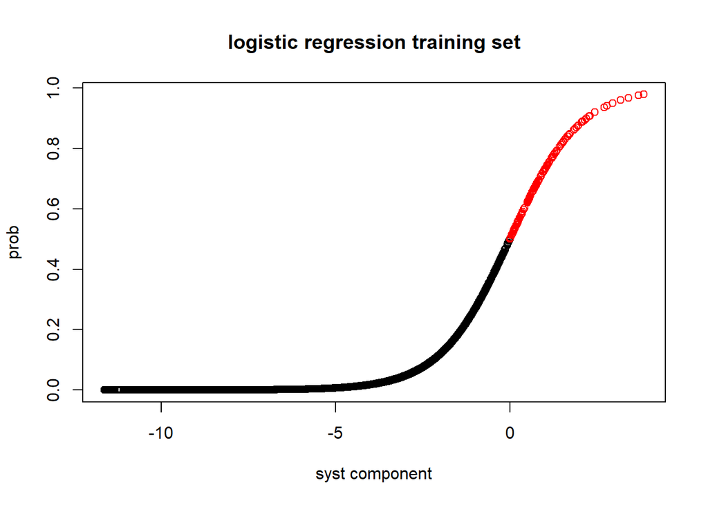

```r
#Make predictions on the training set
pred_logistic_train<-predict(logistic_train,training_data)
df_train<-data.frame(log_value=pred_logistic_train,prob=exp(pred_logistic_train)/(1+exp(pred_logistic_train)),default_pred=rep("No",9500))
levels(df_train$default_pred)=c("No","Yes")
df_train$default_pred[df_train$prob>0.5]="Yes"
#Alternative approach would be df_train$default_pred<-ifelse(df_train$prob>0.5,"Yes","No")
df_train_sorted<-df_train[order(df_train$prob,decreasing = FALSE),]
plot(df_train_sorted$log_value,df_train_sorted$prob,col=df_train_sorted$default_pred,xlab="syst component",ylab="prob",main="logistic regression training set")
```

```r
#Make predictions on the test set
pred_logistic_test<-predict(logistic_train,test_data)
df_test<-data.frame(log_value=pred_logistic_test,prob=exp(pred_logistic_test)/(1+exp(pred_logistic_test)),default_pred=rep("No",501),default=test_data$default)
levels(df_test$default_pred)=c("No","Yes")
df_test$default_pred[df_test$prob>0.5]="Yes"

#Construct a table and look at the percentage of correct predictions
log_pred_table<-table(df_test$default_pred,df_test$default)
print(log_pred_table)
```

```
##
##        No Yes
##   No  479  12
##   Yes   3   7
```

```r
cat((round((log_pred_table[1,1]+log_pred_table[2,2])/sum(log_pred_table)*100,2)),"% of the predictions were correct on the test set")
```

```
## 97.01 % of the predictions were correct on the test set
```

Above we have looked at the performance of the logistic regression model on the testset. We can also apply (Goodness Of Fit) GOF tests, which we will show below. In GLMs the deviance statistic is used as a GOF measure and less straightforward than the coefficient of determination as used in the context of OLS. More specifically the scaled deviance is -2 times the log of the likelihood ratio, i.e. if we have the log likelihood of the full/saturated model (this is a model which contains one coefficient for every observation) denoted by $l_s$ and the log likelihood of the proposed model $l_{pr}$, the scaled deviance $D_s$ is given by $-2(l_{pr}-l_s)$. It can be shown that the scaled deviance asymptotically follows a chi-squared distribution with $(n-k-1)$ degrees of freedom, for $n$ and $k$ being the numbers of parameters in the saturated and proposed models respectively.

More generally the result that $-2(l_{pr}-l_s)$ converges to a chi-squared distribution holds for all nested models (i.e. it holds for all cases in which $l_{pr}$ is a submodel of $l_s$) and is known as Wilks theorem. This means that also -2 times the ratio between the log of the likelihood ratio of the proposed and null model follows a chi-squared distribution. More specifically if we denote the log likelihood of the null model by $l_n$, then $-2(l_n-l_{pr})$ follows a chi-squared distribution with $k$ degrees of freedom (which is the number of covariates). This quantity is very useful as it indicates whether the addition of one or more covariates is significant.

```r
#Look at null, full and proposed model fits
logis_null<- glm(default ~ 1, data=Default, family="binomial")
logis_full<- glm(default ~ ., data=Default, family="binomial")
logis_prop<- glm(default ~ student, data=Default, family="binomial")

#Look at the deviance
logis_null_dev <- logis_null$deviance
logis_full_dev <- logis_full$deviance
logis_prop_dev <- logis_prop$deviance
  #Note that the null deviance can also be obtained as follows
logis_prop$null.deviance
```

```
## [1] 2920.65
```

```r
#Look at the anova table and deviance statistic
anova(logis_null,logis_prop)
```

```
## Analysis of Deviance Table
##
## Model 1: default ~ 1
## Model 2: default ~ student
##   Resid. Df Resid. Dev Df Deviance
## 1      9999     2920.7
## 2      9998     2908.7  1   11.967
```

```r
  #We can calculate the deviance statistics as follows
print(-2*(as.numeric(logLik(logis_null))-as.numeric(logLik(logis_prop))))
```

```
## [1] 11.96665
```

```r
  #Check whether the 'student' variable is significant
1-pchisq(11.967,1)
```

```
## [1] 0.0005415105
```

```r
  #Compare with outcomes of the likelihood ratio test
require("mdscore")
lr.test(logis_null,logis_prop)
```

```
## $LR
## [1] 11.96665
##
## $pvalue
## [1] 0.000541613
##
## attr(,"class")
## [1] "lrt.test"
```

```r
#We can also calculate the log likelihood
  #First calculate for first datarow
lf_pred<-predict(logis_full,Default[1,]) #This is the systematic component
print(exp(lf_pred)/(1+exp(lf_pred))) #This gives the mean estimate
```

```
##           1
## 0.001428724
```

```r
  #Convert response to 1s and 0s
y<-ifelse(Default[,1]=="Yes",1,0)
  #Perform glm on the full dataset
logis_full<- glm(default ~ ., data=Default, family="binomial")

#Note that it is recommended to calculate the log-likelihood directly instead of calculating the likelihood and taking the log over this quantity. The reason is that R will eventually round the likelihood to zero as it becomes smaller and smaller. For the Default dataset this happened somewhere after 9000 datapoints.
loglikel<-0
for(i in 1:nrow(Default)){
  #lf_pred<-predict(logis_full,Default[i,])
  #p<-exp(lf_pred)/(1+exp(lf_pred))
  p<-predict(logis_full,Default[i,],type="response")
  loglikel_i<-log((p^y[i])*((1-p)^(1-y[i])))
  #print(likel_i)
  loglikel<-loglikel+loglikel_i
}

cat("Log-likelihood by R function logLik:",logLik(logis_full))
```

```
## Log-likelihood by R function logLik: -785.7724
```

```r
cat("Log-likelihood as calculated above: ",loglikel)
```

```
## Log-likelihood as calculated above:  -785.7724
```

## Poisson regression

Poisson regression is used to model count data, in this case the link function is the log function, it is therefore also called a log-linear model. Due to this log link it yields a multiplicative exponential model for the mean with a variance around the mean that equals the mean (i.e. heteroskedastic model). Generating count data and applying a poisson regression provides a nice way to get a good understanding of this regression technique.

```r
x = seq(0,6,0.025)
z = 1 + 0.32*x #systematic component
mu = exp(z) #apply log link to determine mean
y = rpois(length(x),mu) #Bringing everything together

#Fit a poisson GLM
df=data.frame(y,x)
glm_poisson<-glm(y~x,family="poisson",data=df)
summary(glm_poisson)
```

```
##
## Call:
## glm(formula = y ~ x, family = "poisson", data = df)
##
## Deviance Residuals:
##     Min       1Q   Median       3Q      Max
## -2.8476  -0.8166  -0.0356   0.6847   2.8594
##
## Coefficients:
##             Estimate Std. Error z value Pr(>|z|)
## (Intercept)  0.96655    0.06026   16.04   <2e-16 ***
## x            0.32407    0.01424   22.76   <2e-16 ***
## ---
## Signif. codes:  0 '***' 0.001 '**' 0.01 '*' 0.05 '.' 0.1 ' ' 1
##
## (Dispersion parameter for poisson family taken to be 1)
##
##     Null deviance: 815.15  on 240  degrees of freedom
## Residual deviance: 248.13  on 239  degrees of freedom
## AIC: 1148.3
##
## Number of Fisher Scoring iterations: 4
```

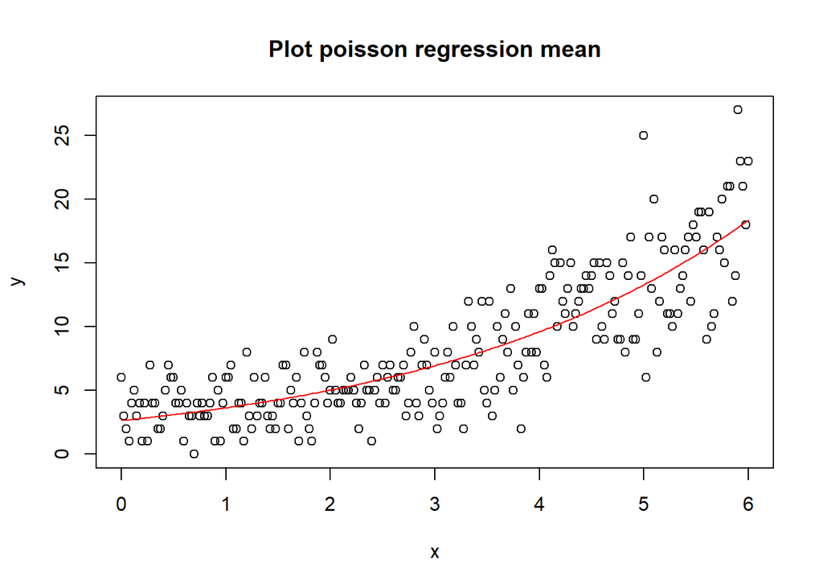

```r
#Make a plot of the fit
df_x<-data.frame(rep(1,length(x)),x)
plot(x,y,main="Plot poisson regression mean")
lines(x,predict(glm_poisson,df_x,type="response"),col="red")
```

Below we will generate data according to a multiplicative model of the form $E(Y_{i,j})=\mu \alpha_i \beta_j$ where $i$ and $j$ are the indices which are the rows and columns and the below example.

```r
i=as.factor(c(1,1,2,2))
j=as.factor(c(1,2,1,2))

alpha=c(1.2,1.6) #row factors
beta=c(2.8,2.4) #column factors
mu=0.3
gen_data=matrix(,2,2)

#Generate the data
gen_data=0.3*alpha%*%t(beta)

pois_mod<-glm(c(gen_data)~i+j,fam=poisson(link=log))

#We calculate the estimates
#Can also be calculated as exp(predict(pois_mod))
gen_00_est=as.numeric(exp(coef(pois_mod)[1]))
gen_10_est=as.numeric(exp(coef(pois_mod)[1]+coef(pois_mod)[2]))
gen_01_est=as.numeric(exp(coef(pois_mod)[1]+coef(pois_mod)[3]))
gen_11_est=as.numeric(exp(coef(pois_mod)[1]+coef(pois_mod)[2]+coef(pois_mod)[3]))

model_table<-matrix(c(gen_00_est,gen_01_est,gen_10_est,gen_11_est),2,2)

#Generated data
print(gen_data)
```

```
##       [,1]  [,2]
## [1,] 1.008 0.864
## [2,] 1.344 1.152
```

```r
#Estimated data
print(model_table)
```

```
##       [,1]  [,2]
## [1,] 1.008 0.864
## [2,] 1.344 1.152
```

```r
#The fit is very good as can be seen from the table and the deviance of the model
print(pois_mod$deviance)
```

```
## [1] 2.202539e-16
```

```r
#Now look at the fit with a linear regression
lm_mod<-lm(c(gen_data)~i+j)

#Look at the OLS estimates, which lead to higher errors in the predictions
predict(lm_mod)
```

```
##     1     2     3     4
## 1.020 1.332 0.852 1.164
```

```r
sum((c(gen_data)-predict(lm_mod))^2)
```

```
## [1] 0.000576
```

## Application: Chain Ladder method and GLM

GLMs are used in non-life insurance for claim reserving in IBNR models. To give some background, claims arising within a certain year will not be finalized in that year and the total claim amount might become known only after many years. For modeling purposes it is therefore administrated what the origin year of a claim is as well as how it develops towards the future. This is done in a so-called run-off triangle.

We are interested in how the claims develop towards the future. Historically the (deterministic) chain ladder method was used in order to make this projection by assuming that claims over development years is proportional. GLMs can however also be used for this purpose, for example by using the origin and development years as covariates. Below we will give an example.

It of course depends on the type of data in the run-off triangle what kind of link function should be chosen. In case of frequency/count data the log-link (poisson regression) is used. The individual and total claim size however require asymmetric distributions with a fat right tail (as should be expected for compound poisson distributions). The Tweedy distribution is for example used for modeling the total claim amount. Below we will only look at the claim frequency.

The (non-stochastic) Chain Ladder model estimations coincide with the (stochastic) poisson regression estimates. They additionally emit the marginal totals property which means that the total number of claims per row for the data and model coincide.

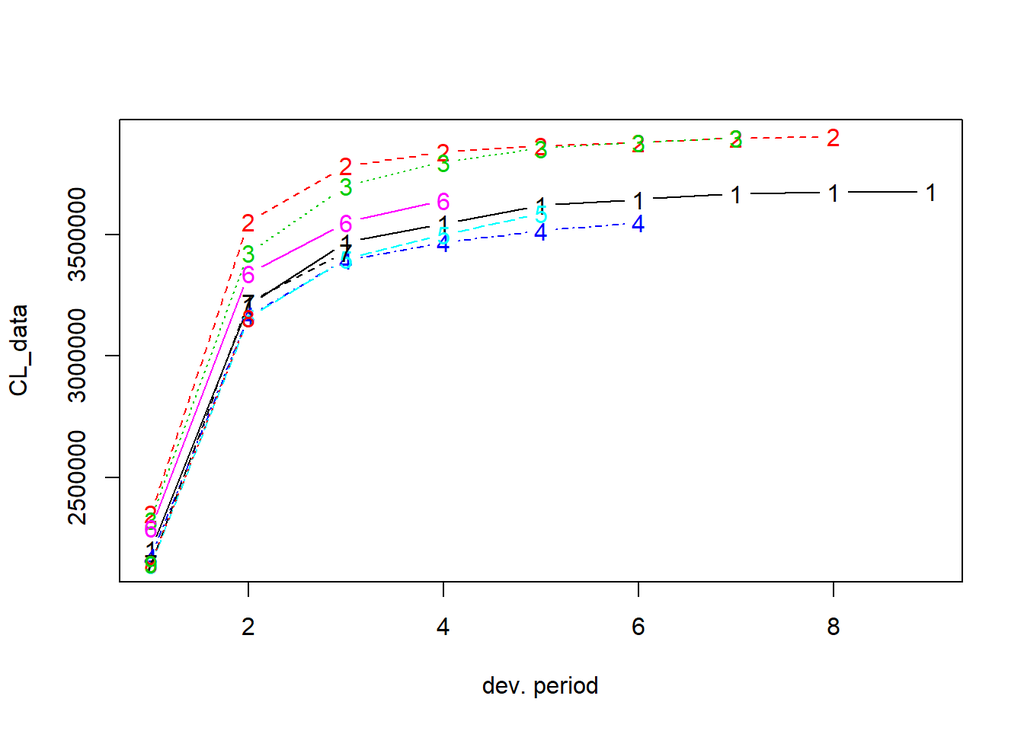

```r
require("ChainLadder")

#load data
data("MW2008")
CL_data<-MW2008
n<-ncol(CL_data)

#plot data
plot(CL_data)
```

```r
#Make cumulative development years now incremental
inc_CL_data <- cum2incr(CL_data)

#Development factors: Note that this is applied to cumulative data(!)
dev_factors<-c()
for(i in 1:(n-1)){
  dev_factors<-c(dev_factors,sum(CL_data[c(1:(n-i)),(i+1)])/sum(CL_data[c(1:(n-i)),i]))
}

#Completing cumulative loss triangle using development factors
cop_CL_data=CL_data

for(i in 2:n){
    cop_CL_data[c(((n+2)-i):n),i]=dev_factors[i-1]*cop_CL_data[c(((n+2)-i):n),(i-1)]
}

#Note that this result can also be obtained with the ChainLadder library using
mack<-MackChainLadder(CL_data)
mack$FullTriangle
```

```
##       dev
## origin       1       2       3       4       5       6       7       8       9
##      1 2202584 3210449 3468122 3545070 3621627 3644636 3669012 3674511 3678633
##      2 2350650 3553023 3783846 3840067 3865187 3878744 3898281 3902425 3906803
##      3 2321885 3424190 3700876 3798198 3854755 3878993 3898825 3903793 3908172
##      4 2171487 3165274 3395841 3466453 3515703 3548422 3568259 3572806 3576814
##      5 2140328 3157079 3399262 3500520 3585812 3608384 3628557 3633180 3637256
##      6 2290664 3338197 3550332 3641036 3699768 3723057 3743871 3748642 3752847
##      7 2148216 3219775 3428335 3507703 3564284 3586720 3606772 3611368 3615419
##      8 2143728 3158581 3385688 3464069 3519946 3542103 3561906 3566444 3570445
##      9 2144738 3165479 3393083 3471634 3527634 3549839 3569685 3574233 3578243
```

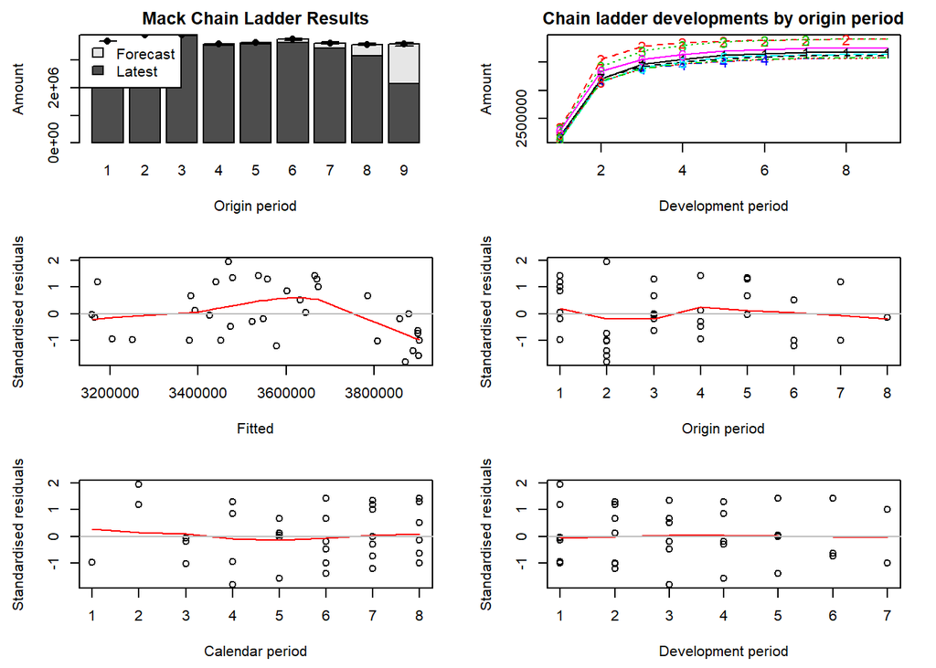

```r
#Package contains an informative plot function
plot(mack)
```

```r
#As we know the ChainLadder approach estimations coincides with the Marginal Totals approach and poisson GLM estimations. Compare the outcomes of a GLM therefore with earlier results.
#Note here that the glmReserve() function requires the cumulative dataset
glm_fit_1<-glmReserve(CL_data)
summary(glm_fit_1,type="model")
```

```
##
## Call:
## glm(formula = value ~ factor(origin) + factor(dev), family = fam,
##     data = ldaFit, offset = offset)
##
## Deviance Residuals:
##      Min        1Q    Median        3Q       Max
## -165.388   -22.326    -1.567    26.984   110.647
##
## Coefficients:
##                 Estimate Std. Error t value Pr(>|t|)
## (Intercept)     14.60620    0.03247 449.880  < 2e-16 ***
## factor(origin)2  0.06018    0.04336   1.388    0.176
## factor(origin)3  0.06053    0.04338   1.395    0.174
## factor(origin)4 -0.02807    0.04443  -0.632    0.533
## factor(origin)5 -0.01131    0.04432  -0.255    0.800
## factor(origin)6  0.01997    0.04419   0.452    0.655
## factor(origin)7 -0.01733    0.04491  -0.386    0.702
## factor(origin)8 -0.02985    0.04600  -0.649    0.522
## factor(origin)9 -0.02767    0.05209  -0.531    0.599
## factor(dev)2    -0.74249    0.02492 -29.794  < 2e-16 ***
## factor(dev)3    -2.24317    0.04862 -46.133  < 2e-16 ***
## factor(dev)4    -3.30702    0.08637 -38.290  < 2e-16 ***
## factor(dev)5    -3.64543    0.11149 -32.698  < 2e-16 ***
## factor(dev)6    -4.57043    0.19589 -23.332  < 2e-16 ***
## factor(dev)7    -4.68280    0.23711 -19.750  < 2e-16 ***
## factor(dev)8    -6.15590    0.60794 -10.126 7.30e-11 ***
## factor(dev)9    -6.28210    0.92971  -6.757 2.45e-07 ***
## ---
## Signif. codes:  0 '***' 0.001 '**' 0.01 '*' 0.05 '.' 0.1 ' ' 1
##
## (Dispersion parameter for Tweedie family taken to be 3558.577)
##
##     Null deviance: 45591337  on 44  degrees of freedom
## Residual deviance:   104316  on 28  degrees of freedom
## AIC: NA
##
## Number of Fisher Scoring iterations: 4
```

```r
#This would give an error: summary(glmReserve(inc_CL_data),type="model")


#We can show that using the GLM function directly we can also obtain these coefficients
#Note that this requires the incremental dataset (can be confusing with GLM)
vec_CL_data<-as.vector(na.omit(as.vector(inc_CL_data)))
col<-rep(1:n,n:1)
row<-sequence(n:1)
glm_fit_2 <- glm(vec_CL_data~as.factor(row)+as.factor(col), family=poisson)
glm_fit_2_coef<-coef(glm_fit_2)
print(glm_fit_2_coef)
```

```
##     (Intercept) as.factor(row)2 as.factor(row)3 as.factor(row)4 as.factor(row)5
##     14.60619727      0.06017809      0.06052865     -0.02806864     -0.01131166
## as.factor(row)6 as.factor(row)7 as.factor(row)8 as.factor(row)9 as.factor(col)2
##      0.01997357     -0.01733341     -0.02985091     -0.02766932     -0.74248829
## as.factor(col)3 as.factor(col)4 as.factor(col)5 as.factor(col)6 as.factor(col)7
##     -2.24316859     -3.30701912     -3.64542703     -4.57042744     -4.68280110
## as.factor(col)8 as.factor(col)9
##     -6.15589857     -6.28210351
```

```r
#Based on the glm coefficients we can fill the triangle
exp_coef <- exp(glm_fit_2_coef)
alpha <- exp_coef[1] * c(1, exp_coef[2:n])
beta <- c(1, exp_coef[(n+1):(2*n-1)])
triangle_2_inc <- alpha %*% t(beta)
triangle_2<-t(apply(triangle_2_inc,1,cumsum))

#glmReserve can also construct the full triangle but does this differently as it leaves realizations unchanged.
triangle_1<-glm_fit_1$FullTriangle
print(triangle_1)
```

```
##       dev
## origin       1       2       3       4       5       6       7       8       9
##      1 2202584 3210449 3468122 3545070 3621627 3644636 3669012 3674511 3678633
##      2 2350650 3553023 3783846 3840067 3865187 3878744 3898281 3902425 3906803
##      3 2321885 3424190 3700876 3798198 3854755 3878993 3898825 3903793 3908172
##      4 2171487 3165274 3395841 3466453 3515703 3548422 3568259 3572806 3576814
##      5 2140328 3157079 3399262 3500520 3585812 3608384 3628557 3633181 3637257
##      6 2290664 3338197 3550332 3641036 3699768 3723057 3743871 3748642 3752847
##      7 2148216 3219775 3428335 3507703 3564284 3586720 3606772 3611368 3615419
##      8 2143728 3158581 3385688 3464068 3519946 3542103 3561905 3566444 3570445
##      9 2144738 3165479 3393082 3471633 3527633 3549839 3569684 3574233 3578243
```

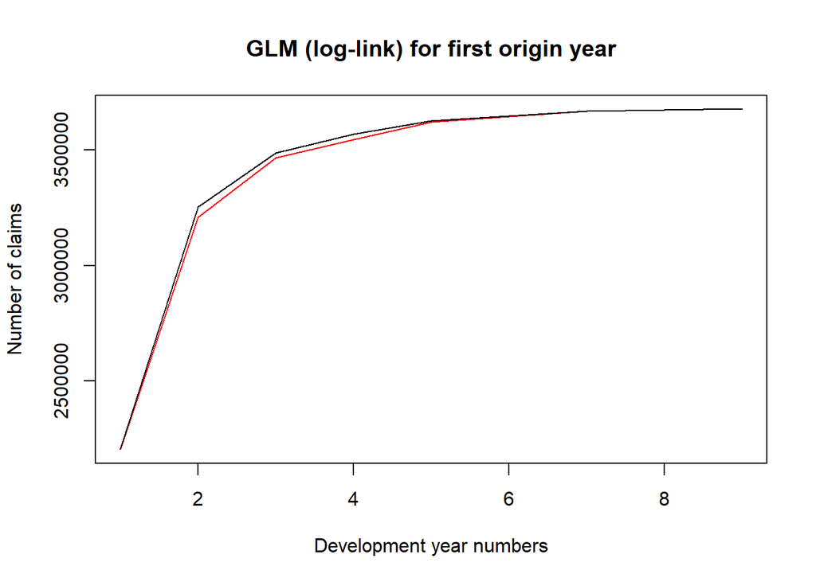

```r
#We can check how well the model fits the data, for example for the first origin year
plot(CL_data[1,],type="l",col="red",main="GLM (log-link) for first origin year",xlab="Development year numbers",ylab="Number of claims")
lines(triangle_2[1,],type="l")
```

```r
#Note that the Marginal Totals property holds, i.e. totals add up
  #This gives the sum of the total incurred claims per origin year
for(i in 1:n){
  print(CL_data[i,((n+1)-i)])
}
```

```
## [1] 3678633
## [1] 3902425
## [1] 3898825
## [1] 3548422
## [1] 3585812
## [1] 3641036
## [1] 3428335
## [1] 3158581
## [1] 2144738
```

```r
  #Compare with the number of claims given by the fit
for(i in 1:n){
  print(as.numeric(triangle_2[i,((n+1)-i)]))
}
```

```
## [1] 3678633
## [1] 3902425
## [1] 3898825
## [1] 3548422
## [1] 3585812
## [1] 3641036
## [1] 3428335
## [1] 3158581
## [1] 2144738
```

## Generalized Additive Models (GAM)

GLMs are a generalization of OLS as we have seen in which a smooth function of a distribution (from the expontential family) is expressed in a linear systematic component. We could further generalize the framework by smoothening the covariates.

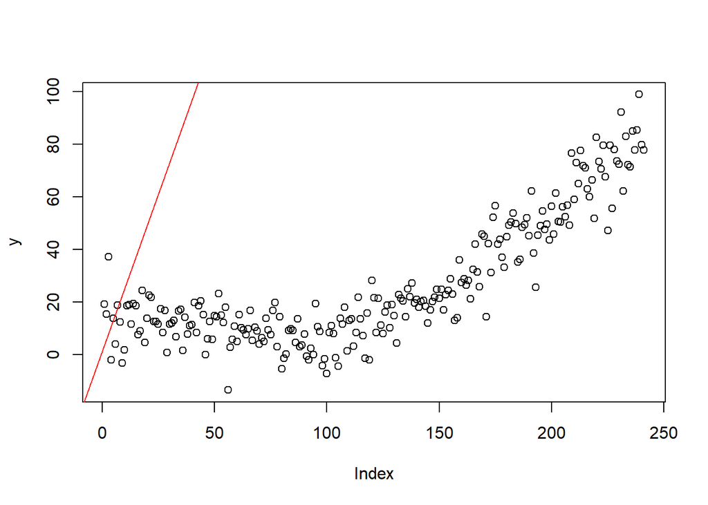

```r
set.seed(1001)
n=500
x1<-seq(0,4,length.out=n)
x2<-seq(0,6,length.out=n)

y<-(-0.2*exp(x1))+3.2*cos(x2)+(x2/6)+rnorm(n)

x1<-1.3*x+rnorm(length(x),0,3)+0.5*(x^2)
x2<-3.2*cos(x)+rnorm(length(x),0,x/3)+(x/6)
y<-1+2.4*x1+3.6*x2+rnorm(length(x))
lm_fit<-lm(y~x1+x2)

#Make plot
plot(y)
abline(lm_fit,col="red")
```

## Mixed Models

```r
#Load the required package
require("lme4")
```

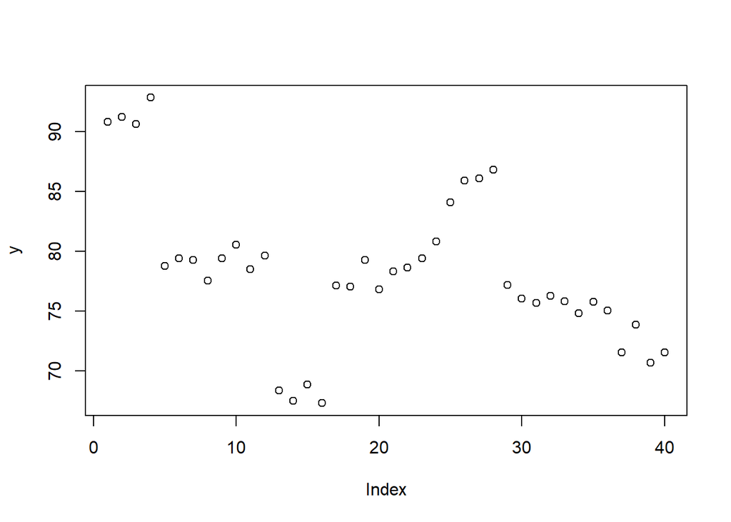

```r
#Assume four doctors that examine ten patients, mean=0, sd=5
set.seed(1001)
patient_fct<-as.factor(rep(1:10,each=4))
patient_ind<-rep(rnorm(10,mean=0,sd=5),each=4)
gender<-as.factor(rep(c(0,1,1,1),each=10)) #Add gender as variable that is not related to the sub-groups
set.seed(1002)
eps<-rnorm(40)
y<-80+patient_ind+eps

#Make a plot to see different levels for subgroups
plot(y)
```

```r
#Make a fit for only fixed effects and mixed (fixed+random) effects
fixed_fit<-lm(y~1)
mixed_fit<-lmer(y~gender+(1|patient_fct))

#Note that in case of mixed effects we get a larger std. error as this model also accounts for the variation between the subgroups.
summary(fixed_fit)
```

```
##
## Call:
## lm(formula = y ~ 1)
##
## Residuals:
##      Min       1Q   Median       3Q      Max
## -11.0819  -2.8481  -0.4634   1.4843  14.4757
##
## Coefficients:
##             Estimate Std. Error t value Pr(>|t|)
## (Intercept)   78.373      1.008   77.75   <2e-16 ***
## ---
## Signif. codes:  0 '***' 0.001 '**' 0.01 '*' 0.05 '.' 0.1 ' ' 1
##
## Residual standard error: 6.375 on 39 degrees of freedom
```

```r
summary(mixed_fit)
```

```
## Linear mixed model fit by REML ['lmerMod']
## Formula: y ~ gender + (1 | patient_fct)
##
## REML criterion at convergence: 155.8
##
## Scaled residuals:
##     Min      1Q  Median      3Q     Max
## -1.6476 -0.5995 -0.1767  0.4678  1.9800
##
## Random effects:
##  Groups      Name        Variance Std.Dev.
##  patient_fct (Intercept) 39.6889  6.2999
##  Residual                 0.9515  0.9755
## Number of obs: 40, groups:  patient_fct, 10
##
## Fixed effects:
##             Estimate Std. Error t value
## (Intercept)  79.2788     2.1232  37.339
## gender1      -1.2080     0.9571  -1.262
##
## Correlation of Fixed Effects:
##         (Intr)
## gender1 -0.338
```

```r
#Looking at the coefficients shows that we have a different intercept coefficient per subgroup. Notice that the gender_1 coefficient stays the same as it doesn't impact the subgroups.
coef(mixed_fit)
```

```
## $patient_fct
##    (Intercept)   gender1
## 1     91.30352 -1.207982
## 2     78.74007 -1.207982
## 3     80.11642 -1.207982
## 4     69.26764 -1.207982
## 5     78.76206 -1.207982
## 6     80.47991 -1.207982
## 7     86.89448 -1.207982
## 8     77.50181 -1.207982
## 9     76.57768 -1.207982
## 10    73.14472 -1.207982
##
## attr(,"class")
## [1] "coef.mer"
```

## Main References

- Elements of statistical learning (2nd edition), T Hastie et al, 2016
- Claims reserving with R: ChainLadder-0.2.11 package vignette, A Carrato et al, 2020
- Modern actuarial risk theory: Using R (2nd edition), R Kaas et al, 2008
- R BGU Course, J Rosenblatt, 2019